# Annotation of virulence factors

Produced with bacannot pipeline

06 July 2024

# ecoli virulence report

## About

Virulence factors are molecules produced by bacteria that add effectiveness in their colonization ability of a niche, immunoevasion, immunosuppression and nutrition obtention from the host. In order to detect these molecules in the query genome its gene sequences were aligned against two databases:

1. [VFDB](http://www.mgc.ac.cn/VFs/main.htm);
   - VFDB is a comprehensive resource, created in 2004, of curated information about virulence factors of pathogenic bacteria. To date, it contains a 1080 virulence factors in its database, from >74 *bacteria genera*.
   - In this pipeline the VFDB nucleotide core dataset (A) was used for alignment.
2. [Victors](http://www.phidias.us/victors/).
   - Victors is a curated database which currently possesses 5296 virulence factors for 194 different pathogens including bacteria, viruses and parasites and is focused in proteins related to interactions pathogen-host.
   - Victors is a protein database, thus scanned with `BLASTp`.

### Prediction thresholds

All the predictions were passed through a user defined threshold for minimum coverage and identity:

- Min. Identity (%): `> 90`
- Min. Coverage (%): `> 90`

> The results used to create this report are under the directory called `virulence` in the output folder of the query ecoli.

## VFDB

All virulence factors (from VFDB) that were found to have at least one gene in the query genome are summarized below. All of them are linked to the database for further investigations. A more detailed information about the virulence annotation with VFDB is given in Table 1. Additionally, Figure 1 summarizes the amount of annotated genes of each virulence factor. Information are always linked to the database to make investigations easier.

> The results are showed as: **VFDB virulence factor name (VFDB virulence factor ID)**.

### Summary

- Virulence factors found in the query genome:
  - [Chu (VF0234) Nutritional/Metabolic factor (VFC0272)](http://www.mgc.ac.cn/cgi-bin/VFs/vfs.cgi?VFID=VF0234)
  - [Curli fibers (VF1138) Adherence (VFC0001)](http://www.mgc.ac.cn/cgi-bin/VFs/vfs.cgi?VFID=VF1138)
  - [ECP (VF0404) Adherence (VFC0001)](http://www.mgc.ac.cn/cgi-bin/VFs/vfs.cgi?VFID=VF0404)
  - [Enterobactin (VF0228) Nutritional/Metabolic factor (VFC0272)](http://www.mgc.ac.cn/cgi-bin/VFs/vfs.cgi?VFID=VF0228)
  - [EspP (VF0208) Effector delivery system (VFC0086)](http://www.mgc.ac.cn/cgi-bin/VFs/vfs.cgi?VFID=VF0208)
  - [FdeC (VF0506) Adherence (VFC0001)](http://www.mgc.ac.cn/cgi-bin/VFs/vfs.cgi?VFID=VF0506)
  - [Hemolysin (VF0207) Exotoxin (VFC0235)](http://www.mgc.ac.cn/cgi-bin/VFs/vfs.cgi?VFID=VF0207)
  - [Ibes (VF0237) Invasion (VFC0083)](http://www.mgc.ac.cn/cgi-bin/VFs/vfs.cgi?VFID=VF0237)
  - [Intimin (VF0202) Effector delivery system (VFC0086)](http://www.mgc.ac.cn/cgi-bin/VFs/vfs.cgi?VFID=VF0202)
  - [Ler (VF0192) Regulation (VFC0301)](http://www.mgc.ac.cn/cgi-bin/VFs/vfs.cgi?VFID=VF0192)
  - [OmpA (VF0236) Invasion (VFC0083)](http://www.mgc.ac.cn/cgi-bin/VFs/vfs.cgi?VFID=VF0236)
  - [Paa (VF0194) Adherence (VFC0001)](http://www.mgc.ac.cn/cgi-bin/VFs/vfs.cgi?VFID=VF0194)
  - [RpoS (VF0112) Regulation (VFC0301)](http://www.mgc.ac.cn/cgi-bin/VFs/vfs.cgi?VFID=VF0112)
  - [Shu (VF0256) Nutritional/Metabolic factor (VFC0272)](http://www.mgc.ac.cn/cgi-bin/VFs/vfs.cgi?VFID=VF0256)
  - [Stx (VF0206) Exotoxin (VFC0235)](http://www.mgc.ac.cn/cgi-bin/VFs/vfs.cgi?VFID=VF0206)
  - [T6SS (VF0579) Effector delivery system (VFC0086)](http://www.mgc.ac.cn/cgi-bin/VFs/vfs.cgi?VFID=VF0579)
  - [TTSS (VF0191) Effector delivery system (VFC0086)](http://www.mgc.ac.cn/cgi-bin/VFs/vfs.cgi?VFID=VF0191)
  - [TTSS secreted effectors (VF1110) Effector delivery system (VFC0086)](http://www.mgc.ac.cn/cgi-bin/VFs/vfs.cgi?VFID=VF1110)
  - [TTSS secreted effectors (VF1111) Effector delivery system (VFC0086)](http://www.mgc.ac.cn/cgi-bin/VFs/vfs.cgi?VFID=VF1111)
  - [ToxB (VF0203) Effector delivery system (VFC0086)](http://www.mgc.ac.cn/cgi-bin/VFs/vfs.cgi?VFID=VF0203)
  - [Type 1 fimbriae (VF0221) Adherence (VFC0001)](http://www.mgc.ac.cn/cgi-bin/VFs/vfs.cgi?VFID=VF0221)

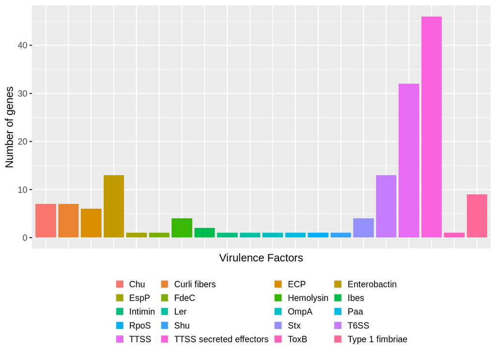

Figure 1: Virulence Factors annotated from [VFDB](http://www.mgc.ac.cn/VFs/main.htm) database

### Detailed information

Table 1: Virulence factors annotated using the VFDB database via BLASTn

| Virulence Factor Name | VF ID | Gene Name | Description | Query Protein ID | Query Protein Coordinates |
| --- | --- | --- | --- | --- | --- |
| RpoS (VF0112) Regulation (VFC0301) | VF0112 | (rpoS) | VFG000477(gb\|NP 461845) (rpoS) RNA polymerase sigma factor RpoS [RpoS (VF0112) Regulation (VFC0301)] | AAPFGBLB_03598 | NC_002695.2:3587209-3588201 |
| TTSS (VF0191) Effector delivery system (VFC0086) | VF0191 | (cesAB) | VFG000830(gb\|WP 001301632) (cesAB) chaperone for EspA and EspB [TTSS (VF0191) Effector delivery system (VFC0086)] | AAPFGBLB_04601 | NC_002695.2:4619351-4619665 |
| TTSS (VF0191) Effector delivery system (VFC0086) | VF0191 | (cesD) | VFG000820(gb\|WP 000087467) (cesD) chaperone for EspB and EspD [TTSS (VF0191) Effector delivery system (VFC0086)] | AAPFGBLB_04591 | NC_002695.2:4613053-4613508 |
| TTSS (VF0191) Effector delivery system (VFC0086) | VF0191 | (cesD2) | VFG000797(gb\|WP 000228583) (cesD2) chaperone for EspD [TTSS (VF0191) Effector delivery system (VFC0086)] | AAPFGBLB_04569 | NC_002695.2:4590754-4591161 |
| TTSS (VF0191) Effector delivery system (VFC0086) | VF0191 | (cesF) | VFG000807(gb\|WP 001003065) (cesF) CesF, chaperone for EspF [TTSS (VF0191) Effector delivery system (VFC0086)] | AAPFGBLB_04579 | NC_002695.2:4603032-4603415 |
| TTSS (VF0191) Effector delivery system (VFC0086) | VF0191 | (cesL) | VFG000814(gb\|WP 001050992) (cesL) chaperone for SepL [TTSS (VF0191) Effector delivery system (VFC0086)] | AAPFGBLB_04585 | NC_002695.2:4609167-4609520 |
| TTSS (VF0191) Effector delivery system (VFC0086) | VF0191 | (cesT) | VFG000804(gb\|WP 000098793) (cesT) multieffector chaperone [TTSS (VF0191) Effector delivery system (VFC0086)] | AAPFGBLB_04576 | NC_002695.2:4599447-4599917 |
| TTSS (VF0191) Effector delivery system (VFC0086) | VF0191 | (escC) | VFG000819(gb\|WP 000723942) (escC) Type III secretion system secretin EscC [TTSS (VF0191) Effector delivery system (VFC0086)] | AAPFGBLB_04590 | NC_002695.2:4611501-4613039 |
| TTSS (VF0191) Effector delivery system (VFC0086) | VF0191 | (escD) | VFG000802(gb\|WP 000953255) (escD) Type III secretion system outer MS ring protein EscD [TTSS (VF0191) Effector delivery system (VFC0086)] | AAPFGBLB_04574 | NC_002695.2:4595099-4596319 |
| TTSS (VF0191) Effector delivery system (VFC0086) | VF0191 | (escE) | VFG000831(gb\|WP 000628731) (escE) chaperone for EscF [TTSS (VF0191) Effector delivery system (VFC0086)] | AAPFGBLB_04602 | NC_002695.2:4619678-4619896 |

[output cut: 142 more lines]

## Victors

All query genes predicted by Prokka that have a match in Victors database are described in Table 2. In order to make further investigations easier, all genes are linked to its matches in Victors database.

> Victors database is protein-only thus genes are scanned via blastp. Victors is a new database and focused in proteins that are important in the interaction pathogen-host, thus it may contain some less known genes.

Table 2: Virulence factors annotated using the Victors database via BLASTp

| Gene Name | Database ID | Product | Query Protein ID | Description | Query Protein Coordinates |
| --- | --- | --- | --- | --- | --- |
| surA from Shigella flexneri 5 str. 8401 | 1811 | peptidyl-prolyl cis-trans isomerase SurA | AAPFGBLB_00055 | gi\|110804119\|ref\|YP_687639.1\|peptidyl-prolyl_cis-trans_isomerase_SurA_[Shigella_flexneri_5_str._8401] | NC_002695.2:58392-59678 |
| dksA from Shigella flexneri 5 str. 8401 | 1806 | DnaK transcriptional regulator DksA | AAPFGBLB_00143 | gi\|110804200\|ref\|YP_687720.1\|RNA_polymerase-binding_transcription_factor_[Shigella_flexneri_5_str._8401] | NC_002695.2:164472-164927 |
| degP | 1655 | protease Do | AAPFGBLB_00159 | gi\|187732326\|ref\|YP_001878964.1\|serine_endoprotease_[Shigella_boydii_CDC_3083-94] | NC_002695.2:185084-186508 |
| map from Escherichia coli O157:H7 str. EDL933 | 2125 | methionine aminopeptidase | AAPFGBLB_00164 | gi\|15799850\|ref\|NP_285862.1\|methionine_aminopeptidase_[Escherichia_coli_O157:H7_str._EDL933] | NC_002695.2:192199-192993 |
| skp | 1664 | chaperone protein Skp | AAPFGBLB_00175 | gi\|187734090\|ref\|YP_001878980.1\|periplasmic_chaperone_[Shigella_boydii_CDC_3083-94] | NC_002695.2:203826-204311 |
| gmhA from Salmonella enterica subsp. enterica serovar Typhimurium str. LT2 | 2596 | phosphoheptose isomerase | AAPFGBLB_00249 | gi\|16763693\|ref\|NP_459308.1\|phosphoheptose_isomerase_[Salmonella_enterica_subsp._enterica_serovar_Typhimurium_str._LT2] | NC_002695.2:281612-282190 |
| dinP | 2597 | DNA polymerase IV | AAPFGBLB_00257 | gi\|16763696\|ref\|NP_459311.1\|DNA_polymerase_IV_[Salmonella_enterica_subsp._enterica_serovar_Typhimurium_str._LT2] | NC_002695.2:288785-289840 |
| matB/ecpA from Escherichia coli O103:H2 str. 12009 | 3772 | putative fimbrillin precursor | AAPFGBLB_00318 | gi\|260842499\|ref\|YP_003220277.1\|fimbrillin_precursor_[Escherichia_coli_O103:H2_str._12009] | NC_002695.2:342493-343080 |
| Z0469 | 2133 | putative structural protein (partial) | AAPFGBLB_00415 | gi\|15800100\|ref\|NP_286112.1\|hypothetical_protein_Z0469_[Escherichia_coli_O157:H7_str._EDL933] | NC_002695.2:451256-454198 |
| cyoB | 2604 | cytochrome o ubiquinol oxidase subunit I | AAPFGBLB_00476 | gi\|16763823\|ref\|NP_459438.1\|cytochrome_o_ubiquinol_oxidase_subunit_I_[Salmonella_enterica_subsp._enterica_serovar_Typhimurium_str._LT2] | NC_002695.2:514704-516695 |

[output cut: 98 more lines]